# Dirichlet regression and the 2018 Quebec Elections (with brms)

Lucas Deschamps

28 septembre 2019

**Disclaimer :** I do not mean to do political analysis, neither to give any opinion. I just made this analysis after the October 2018 provincial election in Quebec, and I decide now to publish it since the R package `brms` implements Dirichlet regression, hoping that my work would encourage ecologists to dive into multivariate models. Enjoy :)

**Note** : I discovered after having writen this post that an article went out in *Methods in Ecology and Evolution* (Douma and Weedon 2019) about regression over proportions. Read this as a tutorial!

```r
# Empty R session
rm(list = ls())
# Set a seed
set.seed(999)
```

# Context

Electors from the Quebec province (Canada) voted in 2018 October 1^st for the members of the national assembly of Quebec. The Coalition Avenir Quebec won the election with 74 seats and 37.42% of votes. They were followed by three principal political party: the Parti Libéral du Québec (31 seats and 24.82% of votes), the Parti Québécois (10 seats, 17.06% of votes) and Quebec Solidaire (10 seats, 16,10%).

For those elections, the Quebec province was divided into 125 electoral divisions ([maps](https://www.electionsquebec.qc.ca/documents/pdf/carte-recto-2017.pdf)). In each of these divisions, voters had to choose a representant belonging to a political party. The representant with the highest number of votes was elected as a member of the national assembly.

In this post, we will explore the relationship between some socio-economic characteristics of each electoral division and the results (in %) of the four principal political party cited above.

To replicate the analysis (and do more if you want!), you simply have to download the .zip file in the [following repository](https://github.com/RIVE-Numeri-lab/RIVE-Numeri-lab.github.io/blob/master/projects/LD_Elections/Dirichlet_Elections.zip).

# Data

## Sources

I compiled data from various sources about the election and the socio-economical characteristics of each electoral division.

Results of the election can be found on the [élections Quebec website](https://www.electionsquebec.qc.ca/francais/provincial/resultats-electoraux/elections-generales.php?e=83&s=1&c=tous#e). I gathered a compilation in a tidy format done by the modeler of the great electoral blog [Qc125](http://canada.qc125.com). The election results are stored in the file `resultats.json` in the zip folder, with the correspondence between geographical and electoral units stored in the `MRC.csv` and `RA.csv` files.

The explanatory variables (socio-economic data) have been gathered from the 2016 censoring, downloadable at this [link](https://www.electionsquebec.qc.ca/francais/provincial/carte-electorale/dossiers-socio-economiques.php) on the élections Quebec website. The data are far from being tidy at all when downloaded at this address. The file `recensement-2016-CEP.xls` in the zip folder contains the original data with a sheet made by copy-pasting data in a tidy format.

The coordinates of each electoral division, defined as the coordinates of the center of the corresponding Municipalité Régional de Comté, can be downloaded on the [Ministère de l’énergie et des ressources naturelles](https://mern.gouv.qc.ca/territoire/portrait/portrait-donnees-mille.jsp) website. The shapefiles are stored in the `MRC` subfolder.

## Preparation

I have prepared functions to be able to put order and assemble data from these different sources.

The first function, `import.result` aims to extract the result of each parti in each region, stored in a Json format, and to join them with geographical informations, such as lattitude and longitude of the electoral division.

```r
import.result <- function(){
  ## Import election results
  D <- rjson::fromJSON(file = "resultats.json",  simplify = T)

  ## Extract the results per electoral division
  Circon <- D$circonscriptions

  ## Prepare a data.frame to store results
  result <- data.frame(circon = rep(NA, length(Circon)), num_circon = NA,
                       CAQ = NA, PQ = NA, PLQ = NA, QS = NA)
  colnames(result)

  for(i in seq(length(Circon))){
    ## Store the electoral division name
    result$circon[i] <- Circon[[i]]$nomCirconscription
    ## Store the electoral division number
    result$num_circon <- Circon[[i]]$numeroCirconscription
    ## Extract results for each candidats
    candidats <- Circon[[i]]$candidats
    for(j in seq(length(candidats))){
      if(candidats[[j]]$numeroPartiPolitique == 27) result$CAQ[i] <- candidats[[j]]$tauxVote
      if(candidats[[j]]$numeroPartiPolitique == 8) result$PQ[i] <- candidats[[j]]$tauxVote
      if(candidats[[j]]$numeroPartiPolitique == 6) result$PLQ[i] <- candidats[[j]]$tauxVote
      if(candidats[[j]]$numeroPartiPolitique == 40) result$QS[i] <- candidats[[j]]$tauxVote
    }
  }

  ## Match electoral division and administrative regions
  regions <- read.csv("RA.csv")
  result <- left_join(result, regions)

  ## Match electoral division and MRC divisions
  MRC <- read.csv("MRC.csv")
  colnames(MRC)[2] <- "circon"
  result <- left_join(result, select(MRC, circon, MRC) )

  ## Get Coordinates of each MRC
  shape <- readOGR("MRC/", "mrc_point")
  D_shape <- cbind(shape@data, shape@coords)
  colnames(D_shape)[8] <- "MRC"

  result <- left_join(result, select(D_shape, MRC, coords.x1, coords.x2))

  return(result)
}
```

The second function import explanatory variables. Because most of these variables are proportions, defined on (0,1), I decided to scale every variable of other kinds under the same range. To constrain a vector $x$ between $a$ and $b$, we need the following function :

$$f(x) = \frac{(b-a) * (x - min(x))}{max(x) - min(x)}$$

```r
## Function to normalize data between a and b
normalize <- function(x, a = 0, b = 1){
  top <- (b-a) * (x - min(x, na.rm = T))
  bot <- max(x, na.rm = T) - min(x, na.rm = T)
  y <- top/bot + a
}

## And function to denormalize
denormalize <- function(x,minval,maxval) {
    x*(maxval-minval) + minval
}

## Import explanatory data
import.X <- function(){
  X1 <- read.csv("explain.csv",sep = ",")

  X <- X1 %>% mutate(taux_actif = taux_actif/100,
                     taux_emploi = taux_emploi/100,
                     n_valeur_logement_mediane = normalize(valeur_logement_mediane),
                     n_cout_hab_loc_pourc = normalize(cout_hab_loc_pourc))
  return(X)
}
```

`n_valeur_logement_mediane` is the median of the estate value in the division and `cout_hab_loc_pourc` is the median value of the domiciliary rent, both defined on $(0,+\infty)$.

# Model

## Beta distibution

Results are proportions, defined on (0,1). A nice way to model proportion is to use a $Beta$ distribution for likelihood. One can define the Beta distribution in term of mean $\mu$ (defined in (0,1)) and a positive precision $\phi$. The following function compute the likelihood of a proportion, $y$, given a mean and a precision (found in [Paul Buerkner’s `vignette`](https://cran.r-project.org/web/packages/brms/vignettes/brms_families.html) about parametrization of distributions, see also Ferrari and Cribari-Neto (2004)) :

$$P(y|\mu, \phi) = \frac{y^{\mu \phi - 1} (1-y)^{(1-\mu) \phi-1}}{B(\mu \phi, (1-\mu) \phi)}$$
$B()$ being the Beta function. An intuition emerges if we focus on the numerator. We can see that the likelihood of a probability $y$ is described as the observation risen at $\mu\phi-1$ multiplied by the complement, $(1-y)$ raised to $(1-\mu)\phi-1$. The first part is a simple exponential function, defined for any value of $y$ over $(-Inf, +Inf)$.

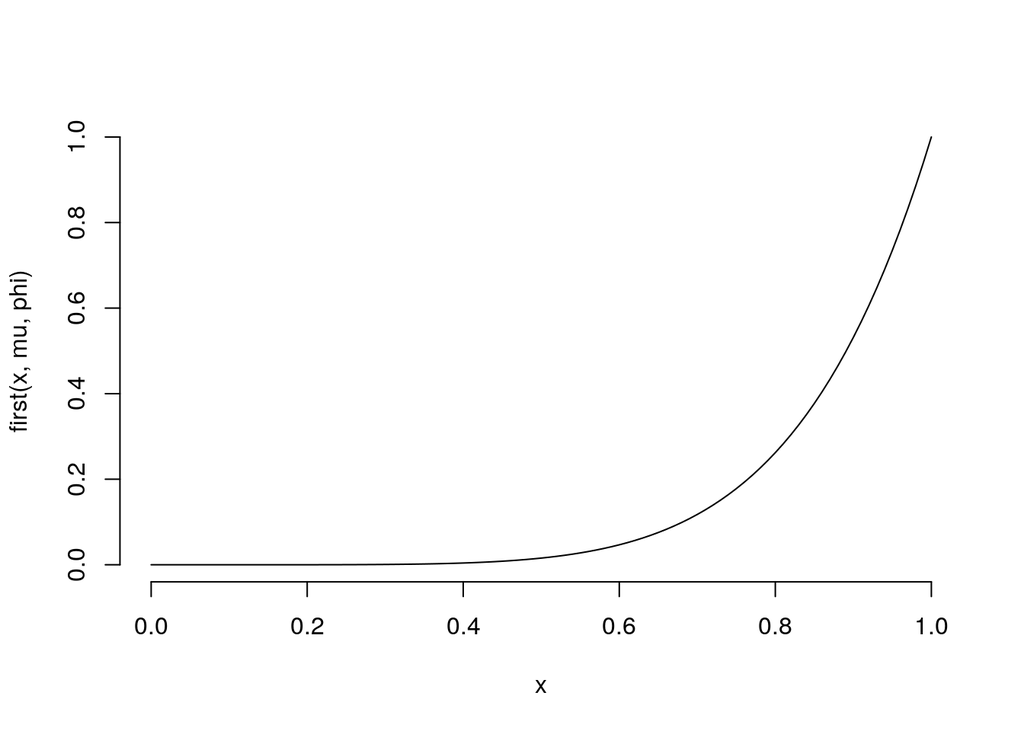

```r
first <- function(x, mu, phi) x^(mu*phi-1)
mu = 0.7; phi = 10
curve(first(x, mu, phi), from = 0, to = 1, bty = "n")
```

This allows the distribution to move around the (0,1) interval by skewing more and more while the mean approaches the boundaries.

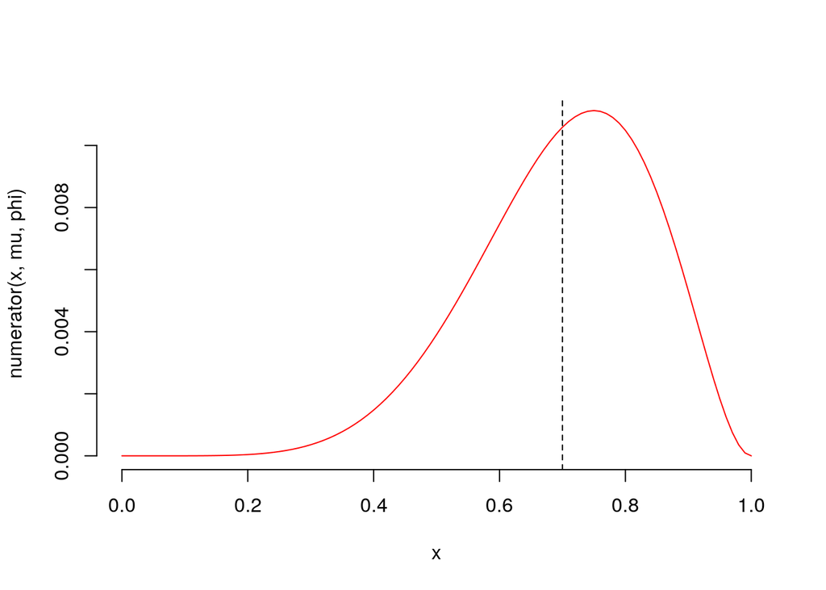

```r
numerator <- function(x, mu, phi) x^(mu*phi-1) * (1-x)^((1-mu)*phi-1)
mu = 0.7; phi = 10
curve(numerator(x, mu, phi), from = 0, to = 1, col = "red", bty = "n")
abline(v = mu, lty = 2)
```

Then, the denominator scales the function to ensure that the area under the curve sum to 1, such as any probability density function shall.

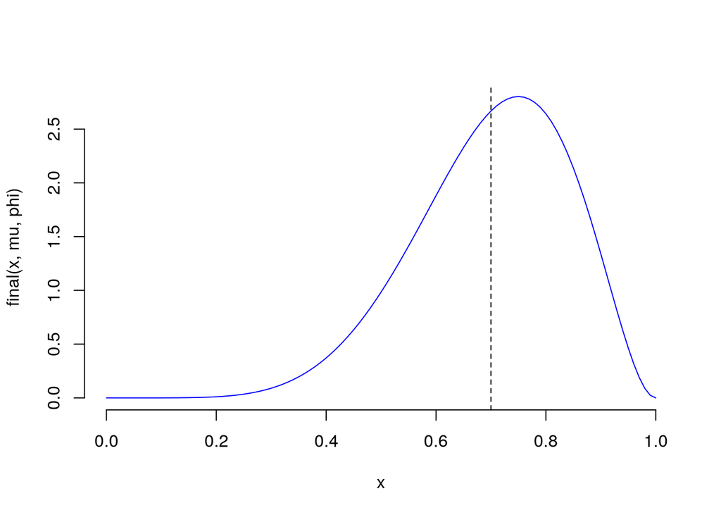

```r
final <- function(x, mu, phi){
  numerator <- numerator(x, mu, phi)
  denominator <- beta(mu*phi, (1-mu)*phi)
  result <- numerator / denominator
}
mu = 0.7; phi = 10
curve(final(x, mu, phi), col = "blue", from = 0, to = 1, bty = "n")
abline(v = 0.7, lty = 2)
```

```r
integrate(numerator, lower = 0, upper = 1, mu = 0.7, phi = 10)
```

```
## 0.003968254 with absolute error < 4.4e-17
```

```r
integrate(final, lower = 0, upper = 1, mu = 0.7, phi = 10)
```

```
## 1 with absolute error < 1.1e-14
```

We can make sense of the mean and dispersion parameters we the following plots. In `R`, the beta distribution is not parameterized by $\mu$ and $\phi$, but by two shape parameter we will recover easily with the function such as $a = \mu * \phi$ and $b = (1-\mu)*\phi$ :

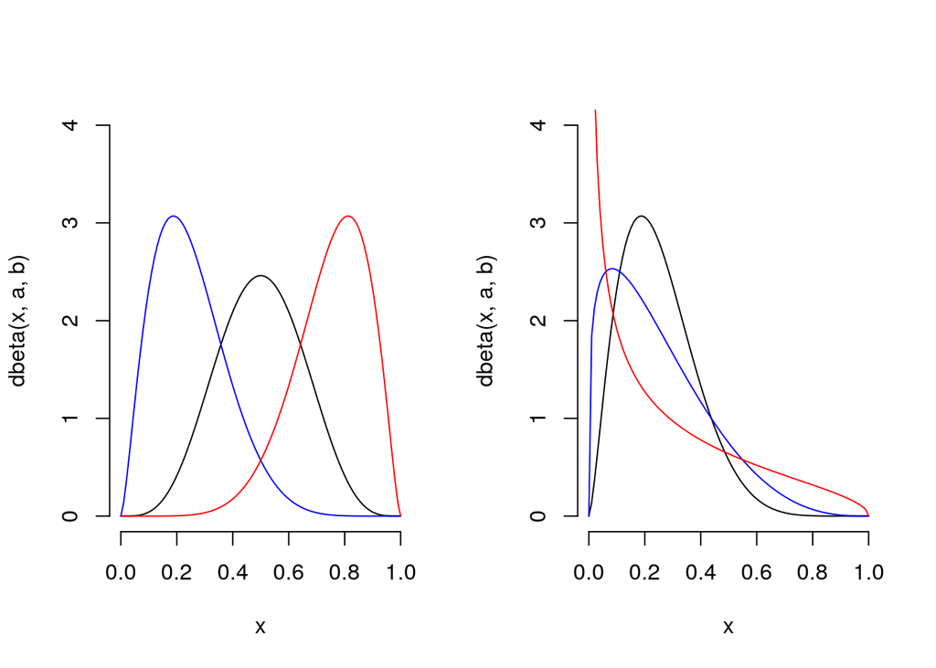

```r
par(mfrow = c(1,2), bty = "n")
mu = 0.5; phi = 10; a = mu*phi; b = (1-mu)*phi
curve(dbeta(x, a, b), ylim = c(0,4))
mu = 0.25; phi = 10; a = mu*phi; b = (1-mu)*phi
curve(dbeta(x, a, b), add = T, col = "blue")
mu = 0.75; phi = 10; a = mu*phi; b = (1-mu)*phi
curve(dbeta(x, a, b), add = T, col = "red")

mu = 0.25; phi = 10; a = mu*phi; b = (1-mu)*phi
curve(dbeta(x, a, b), ylim = c(0,4))
mu = 0.25; phi = 5; a = mu*phi; b = (1-mu)*phi
curve(dbeta(x, a, b), add = T, col = "blue")
mu = 0.25; phi = 2; a = mu*phi; b = (1-mu)*phi
curve(dbeta(x, a, b), add = T, col = "red")
```

```r
par(mfrow = c(1,1))
```

## Dirichlet distribution

But election results are not only proportions, they are *compositional*. As such, each party result is a proportion of the total number of votes in an electoral division : the sum of the proportions have to sum to 1. This is an interesting mathematical property we should exploit while modeling such data. In that case, the proportion of votes a party received in a division is not only constrained by the predictors, the socio-enconomic data, but also by the sum of the proportions of the other parties. This aspect is implemented in the dirichlet distribution, defined as following in a regression framework (see the [`vignette`](https://cran.r-project.org/web/packages/brms/vignettes/brms_families.html) or [(Maier 2014)](http://epub.wu.ac.at/4077/1/Report125.pdf)) :

$$P(y_{c}|\mu_{c}, \phi) = \frac{1}{B((\mu_{1}, \ldots, \mu_{C}) \phi)}
\prod_{d=1}^C y_{}^{\mu_{d} \phi - 1}$$
Where $c$ is the component (column of the simplex matrix) and $B$ the multivariate beta function.

Again, we can make sense of parameters by observing the [distribution](https://en.wikipedia.org/wiki/Dirichlet_distribution#/media/File:Dirichlet-3d-panel.png). In `R`, the distribution is parametrized by a vector $\boldsymbol{\alpha}$, such as $\boldsymbol{\alpha} = \boldsymbol{\mu}\phi$. Where $\boldsymbol{\mu}$ is a simplex reparting the strictly positive value $\phi$, which represents the sum of $\boldsymbol{\alpha}$ such as $\phi = \sum_{c = 1}^{C} \alpha_{c}$.

## Dirichlet regression

We can now formulate a dirichlet regression with $\mu$ dependant of a set of covariates :

$$y_{i,c} \sim Dirichlet(\mu_{i,c}, \phi)\\
\mu_{c,i} = \frac{\exp(\eta_{c,i})}{\sum_{d= 1}^{C} \exp(\eta_{i,d})}\\
\eta_{c,i} = \boldsymbol{\beta_{c}} X_{i}$$

# Dirichlet regression with `brms`

## Data preparation

Let’s first import the election results, with geographical information on each electoral division. Because results are expressed as a percentage, we will divide them by 100.

```r
library(tidyverse)
library(rgdal)
library(knitr)
library(kableExtra)
R <- import.result() %>%
  mutate_at(c("CAQ", "PQ", "PLQ", "QS"), function(x) x/100) %>%
  rename(division = circon)
R %>% head() %>%
  kable() %>%
  kable_styling() %>%
  scroll_box(width = "100%", height = "300px")
```

| division | num_circon | CAQ | PQ | PLQ | QS | CODE_CIRC | CODE_RA | RA | TRI_CIRC | TRI_RA | MRC | coords.x1 | coords.x2 |
| --- | --- | --- | --- | --- | --- | --- | --- | --- | --- | --- | --- | --- | --- |
| Abitibi-Est | 332 | 0.4272 | 0.1948 | 0.1875 | 0.1566 | 648 | 8 | Abitibi-Témiscamingue | ABITIBIEST | ABITIBITEMISCAMINGUE | La Vallée-de-l’Or | -76.75412 | 47.91909 |
| Abitibi-Ouest | 332 | 0.3412 | 0.3326 | 0.1131 | 0.1659 | 642 | 8 | Abitibi-Témiscamingue | ABITIBIOUEST | ABITIBITEMISCAMINGUE | Abitibi | -78.00822 | 48.61578 |
| Acadie | 332 | 0.1651 | 0.0900 | 0.5380 | 0.1375 | 338 | 6 | Montréal | ACADIE | MONTREAL | Montréal | -73.69991 | 45.49017 |
| Anjou-Louis-Riel | 332 | 0.2891 | 0.1470 | 0.3906 | 0.1453 | 366 | 6 | Montréal | ANJOULOUISRIEL | MONTREAL | Montréal | -73.69991 | 45.49017 |
| Argenteuil | 332 | 0.3888 | 0.2114 | 0.1741 | 0.1217 | 520 | 15 | Laurentides | ARGENTEUIL | LAURENTIDES | Argenteuil | -74.45213 | 45.66901 |
| Arthabaska | 332 | 0.6184 | 0.0940 | 0.1135 | 0.1258 | 144 | 17 | Centre-du-Québec | ARTHABASKA | CENTREDUQUEBEC | Arthabaska | -71.88812 | 46.01932 |

Because we only selected the four major political parties, all the rows but two does not sum to one, as simplex should.

```r
(RSums <- R %>% select(CAQ:QS) %>% rowSums())
```

```
##   [1] 0.9661 0.9528 0.9306 0.9720 0.8960 0.9517 0.9421 0.9341 0.9632 0.9577
##  [11] 0.9711 0.9648 0.9601 0.9499 0.9631 0.9426 0.9690 0.9658 0.9627 0.9556
##  [21] 0.9790 0.9581 0.9821 0.9580 0.8908 0.9684 0.9374 0.9424 0.9659 0.9053
##  [31] 0.9447 0.9687 0.9584 0.9832 0.9435 1.0000 0.9417 0.9538 0.9679 0.9390
##  [41] 0.9687 0.9230 0.9667 0.9479 1.0000 0.8829 0.9429 0.9620 0.9479 0.9504
##  [51] 0.9788 0.9794 0.9739 0.9837 0.9837 0.9791 0.9174 0.9482 0.9449 0.9583
##  [61] 0.9645 0.9358 0.9463 0.9698 0.9679 0.9374 0.9321 0.9470 0.9608 0.9609
##  [71] 0.9058 0.9523 0.9709 0.9787 0.9626 0.9588 0.9238 0.9533 0.9662 0.9752
##  [81] 0.9322 0.9205 0.9240 0.9591 0.8829 0.9525 0.9564 0.9858 0.9055 0.9387
##  [91] 0.9831 0.9893 0.9707 0.9750 0.9619 0.9858 0.9892 0.9278 0.9634 0.9601
## [101] 0.9781 0.9711 0.9690 0.9204 0.9881 0.9657 0.9598 0.9222 0.9541 0.9534
## [111] 0.9701 0.9692 0.9477 0.9626 0.9680 0.9744 0.9652 0.9395 0.9618 0.9282
## [121] 0.9265 0.9674 0.9246 0.9500 0.9547 0.9171
```

To solve this, we will create a new column representing the cumulative proportion of votes obtained by all the other parties. Note that this is a personal choice and not the only nor the best solution to analyse the dataset (but definitly one of the simplest).

```r
## Create a new column for others votes
R <- R %>% mutate(Others = 1 - RSums)
R %>% select(CAQ:QS, Others) %>% rowSums()
```

```
##   [1] 1 1 1 1 1 1 1 1 1 1 1 1 1 1 1 1 1 1 1 1 1 1 1 1 1 1 1 1 1 1 1 1 1 1 1
##  [36] 1 1 1 1 1 1 1 1 1 1 1 1 1 1 1 1 1 1 1 1 1 1 1 1 1 1 1 1 1 1 1 1 1 1 1
##  [71] 1 1 1 1 1 1 1 1 1 1 1 1 1 1 1 1 1 1 1 1 1 1 1 1 1 1 1 1 1 1 1 1 1 1 1
## [106] 1 1 1 1 1 1 1 1 1 1 1 1 1 1 1 1 1 1 1 1 1
```

However, two lines were summing to one indicate divisions in which there was no other party than the four major ones or at least no vote for eventual ones. They will cause trouble later in our analysis, because dirichlet regression as defined in `brms` in not define for a proportion of zero. Some solutions exist to accomodate the problem :

- Using a Zero Inflated Dirichlet distribution. The function `ZIGDM` in the [`miLineage`](https://cran.r-project.org/web/packages/miLineage/miLineage.pdf) package can perform such an analysis;
- Using a zero adjusted dirichlet regression [(Tsagris and Stewart 2018)](https://arxiv.org/pdf/1410.5011.pdf)
- Remove the lines.

We will choose the third one for sake of simplicity, reducing the number of line from 126 to 124.

```r
## Remove divisions in which there was no vote for other parties
R_rm <- R %>% filter(Others != 0)
```

Then we will now import the socio-economic variables, and select some :

```r
X_raw <- import.X()

X <- X_raw %>% select(division,
                      anglais_pourc, bilingue_pourc, aucune_pourc,
                      commun_pourc, bicycle_pourc,
                      migrants_5ans_pourc,
                      log_av60_pourc,
                      agri_pourc,
                      moins_40mille_pourc, X40_100mille_pour,
                      loc_pourc,
                      n_valeur_logement_mediane, valeur_logement_mediane,
                      n_cout_hab_loc_pourc, cout_hab_loc_pourc)
```

- `anglais_pourc`, `bilingue_pourc` and `aucune_pourc` are the proportion of person in a division speaking only English, English and French or none of these languages, respectively;
- `commun_pourc` and `bicycle_pourc` are the proportion of people going to work by public transportation or bicycle, respectively;
- `migrants_5ans_pourc` is the proportion of people who have migrated from another country for more than five years;
- `log_av60_pourc` is the proportion of habitation built before 1960;
- `agri_pourc` is the percentage of people working in the agricultural sector;
- `moins_40mille_pourc` and `X40_100mille_pourc` are the proportion of people earning less than 40 000 CAD or between 40 000 and 100 000 CAD, respectively;
- `loc_pourc` is the proportion of people renting their housing;
- `n_valeur_logement_mediane` and `n_cout_hab_loc_pourc` are the median cost of estate and of the housing rent, respectively.

```r
Tot <- left_join(R_rm, X)

Tot %>% select(-CODE_CIRC, -CODE_RA, -TRI_CIRC, -TRI_RA, -MRC) %>%
  summary() %>%
  kable() %>%
  kable_styling() %>%
  scroll_box(width = "100%", height = "300px")
```

division

num_circon

[output not shown]

[output not shown]

[output not shown]

[output not shown]

[output not shown]

coords.x1

coords.x2

[output not shown]

anglais_pourc

bilingue_pourc

aucune_pourc

commun_pourc

bicycle_pourc

migrants_5ans_pourc

log_av60_pourc

agri_pourc

moins_40mille_pourc

X40_100mille_pour

loc_pourc

n_valeur_logement_mediane

valeur_logement_mediane

n_cout_hab_loc_pourc

cout_hab_loc_pourc

Length:124

Min. :332

Min. :0.0640

Min. :0.0256

Min. :0.0522

Min. :0.0434

Montréal :27

Min. :-79.05

Min. :45.14

Min. :0.01070

Min. :0.001759

Min. :0.00000

Min. :0.000000

Min. :0.0000

Min. :0.00000

Min. :0.00000

Min. :0.0400

Min. :0.00000

Min. :0.1300

Min. :0.2700

Min. :0.1400

Min. :0.0000

Min. :129719

Min. :0.0000

Min. : 499.0

Class :character

1st Qu.:332

1st Qu.:0.2643

1st Qu.:0.1003

1st Qu.:0.1283

1st Qu.:0.1151

Montérégie :22

1st Qu.:-73.70

1st Qu.:45.49

1st Qu.:0.03130

1st Qu.:0.012114

1st Qu.:0.00000

1st Qu.:0.000000

1st Qu.:0.0100

1st Qu.:0.00000

1st Qu.:0.01000

1st Qu.:0.1375

1st Qu.:0.00000

1st Qu.:0.2375

1st Qu.:0.4300

1st Qu.:0.2200

1st Qu.:0.1233

1st Qu.:199814

1st Qu.:0.1985

1st Qu.: 609.8

Mode :character

Median :332

Median :0.3921

Median :0.1454

Median :0.2061

Median :0.1424

Capitale-Nationale :11

Median :-73.51

Median :45.62

Median :0.04140

Median :0.045082

Median :0.01000

Median :0.000000

Median :0.0700

Median :0.01000

Median :0.02000

Median :0.2400

Median :0.01000

Median :0.3200

Median :0.4500

Median :0.2850

Median :0.2174

Median :253241

Median :0.4104

Median : 728.0

NA

Mean :332

Mean :0.3635

Mean :0.1721

Mean :0.2560

Mean :0.1620

Lanaudière : 9

Mean :-72.95

Mean :46.35

Mean :0.04644

Mean :0.111924

Mean :0.03113

Mean :0.007984

Mean :0.1271

Mean :0.01387

Mean :0.03565

Mean :0.2435

Mean :0.02145

Mean :0.3063

Mean :0.4454

Mean :0.3658

Mean :0.2443

Mean :268551

Mean :0.3756

Mean : 708.6

NA

3rd Qu.:332

3rd Qu.:0.4716

3rd Qu.:0.2152

3rd Qu.:0.3351

3rd Qu.:0.1696

Laurentides : 8

3rd Qu.:-71.82

3rd Qu.:46.72

3rd Qu.:0.05767

3rd Qu.:0.163318

3rd Qu.:0.05000

3rd Qu.:0.010000

3rd Qu.:0.2100

3rd Qu.:0.01000

3rd Qu.:0.05000

3rd Qu.:0.3125

3rd Qu.:0.03000

3rd Qu.:0.3700

3rd Qu.:0.4700

3rd Qu.:0.4625

3rd Qu.:0.3032

3rd Qu.:302040

3rd Qu.:0.5206

3rd Qu.: 789.5

NA

Max. :332

Max. :0.6637

Max. :0.6946

Max. :0.7432

Max. :0.5914

Chaudière-Appalaches: 7

Max. :-66.71

Max. :58.53

Max. :0.11710

Max. :0.664920

Max. :0.16000

Max. :0.060000

Max. :0.4700

Max. :0.15000

Max. :0.31000

Max. :0.6300

Max. :0.11000

Max. :0.4900

Max. :0.5100

Max. :0.7500

Max. :1.0000

Max. :698017

Max. :1.0000

Max. :1057.0

NA

NA

NA

NA

NA

NA

(Other) :40

NA

NA

NA

NA

NA

NA

NA

NA

NA

NA

NA

NA

NA

NA

NA

NA

NA

NA

To fit a Dirichlet regression with `brms`, one has to format response data in a quite unusual way: the function asks for the response variables to be stores as a data frame inside a data frame!

```r
Tot$Y <- cbind(Others = Tot$Others, CAQ = Tot$CAQ,
               PQ = Tot$PQ, PLQ = Tot$PLQ, QS = Tot$QS)
str(Tot)
```

```
## 'data.frame':    124 obs. of  31 variables:
##  $ division                 : chr  "Abitibi-Est" "Abitibi-Ouest" "Acadie" "Anjou-Louis-Riel" ...
##  $ num_circon               : num  332 332 332 332 332 332 332 332 332 332 ...
##  $ CAQ                      : num  0.427 0.341 0.165 0.289 0.389 ...
##  $ PQ                       : num  0.195 0.333 0.09 0.147 0.211 ...
##  $ PLQ                      : num  0.188 0.113 0.538 0.391 0.174 ...
##  $ QS                       : num  0.157 0.166 0.138 0.145 0.122 ...
##  $ CODE_CIRC                : int  648 642 338 366 520 144 806 802 218 822 ...
##  $ CODE_RA                  : int  8 8 6 6 15 17 12 12 16 12 ...
##  $ RA                       : Factor w/ 17 levels "Abitibi-Témiscamingue",..: 1 1 14 14 10 4 5 5 13 5 ...
##  $ TRI_CIRC                 : Factor w/ 125 levels "ABITIBIEST","ABITIBIOUEST",..: 1 2 3 4 5 6 7 8 9 10 ...
##  $ TRI_RA                   : Factor w/ 17 levels "ABITIBITEMISCAMINGUE",..: 1 1 14 14 10 4 5 5 13 5 ...
##  $ MRC                      : chr  "La Vallée-de-l'Or" "Abitibi" "Montréal" "Montréal" ...
##  $ coords.x1                : num  -76.8 -78 -73.7 -73.7 -74.5 ...
##  $ coords.x2                : num  47.9 48.6 45.5 45.5 45.7 ...
```

[output cut: 20 more lines]

## Model formulation

We can now formulate the posterior stan will explore! We will first begin by the formula of the model.

```r
library(brms)
form <- bf(Y ~ anglais_pourc + bilingue_pourc + aucune_pourc +
                      commun_pourc + bicycle_pourc +
                      migrants_5ans_pourc +
                      log_av60_pourc +
                      agri_pourc +
                      moins_40mille_pourc + X40_100mille_pour +
                      loc_pourc + n_valeur_logement_mediane + n_cout_hab_loc_pourc,
           family = dirichlet)
```

### Priors

Then, we will explore the parameters implied by our formula, and thus the priors we have to define. We can observe that the `Others` column is absent, its parameters being only computed by contrasts from the others.

```r
get_prior(form, data = Tot) %>%
  kable() %>%
  kable_styling() %>%
  scroll_box(width = "100%", height = "300px")
```

| prior | class | coef | group | resp | dpar | nlpar | bound |
| --- | --- | --- | --- | --- | --- | --- | --- |
|  | b |  |  |  |  |  |  |
|  | Intercept |  |  |  |  |  |  |
| gamma(0.01, 0.01) | phi |  |  |  |  |  |  |
|  | b |  |  |  | muCAQ |  |  |
|  | b | agri_pourc |  |  | muCAQ |  |  |
|  | b | anglais_pourc |  |  | muCAQ |  |  |
|  | b | aucune_pourc |  |  | muCAQ |  |  |
|  | b | bicycle_pourc |  |  | muCAQ |  |  |
|  | b | bilingue_pourc |  |  | muCAQ |  |  |
|  | b | commun_pourc |  |  | muCAQ |  |  |
|  | b | loc_pourc |  |  | muCAQ |  |  |
|  | b | log_av60_pourc |  |  | muCAQ |  |  |
|  | b | migrants_5ans_pourc |  |  | muCAQ |  |  |
|  | b | moins_40mille_pourc |  |  | muCAQ |  |  |
|  | b | n_cout_hab_loc_pourc |  |  | muCAQ |  |  |
|  | b | n_valeur_logement_mediane |  |  | muCAQ |  |  |
|  | b | X40_100mille_pour |  |  | muCAQ |  |  |
|  | Intercept |  |  |  | muCAQ |  |  |
|  | b |  |  |  | muPLQ |  |  |
|  | b | agri_pourc |  |  | muPLQ |  |  |
|  | b | anglais_pourc |  |  | muPLQ |  |  |
|  | b | aucune_pourc |  |  | muPLQ |  |  |
|  | b | bicycle_pourc |  |  | muPLQ |  |  |
|  | b | bilingue_pourc |  |  | muPLQ |  |  |
|  | b | commun_pourc |  |  | muPLQ |  |  |
|  | b | loc_pourc |  |  | muPLQ |  |  |
|  | b | log_av60_pourc |  |  | muPLQ |  |  |
|  | b | migrants_5ans_pourc |  |  | muPLQ |  |  |
|  | b | moins_40mille_pourc |  |  | muPLQ |  |  |
|  | b | n_cout_hab_loc_pourc |  |  | muPLQ |  |  |
|  | b | n_valeur_logement_mediane |  |  | muPLQ |  |  |
|  | b | X40_100mille_pour |  |  | muPLQ |  |  |
|  | Intercept |  |  |  | muPLQ |  |  |
|  | b |  |  |  | muPQ |  |  |
|  | b | agri_pourc |  |  | muPQ |  |  |
|  | b | anglais_pourc |  |  | muPQ |  |  |
|  | b | aucune_pourc |  |  | muPQ |  |  |
|  | b | bicycle_pourc |  |  | muPQ |  |  |
|  | b | bilingue_pourc |  |  | muPQ |  |  |
|  | b | commun_pourc |  |  | muPQ |  |  |
|  | b | loc_pourc |  |  | muPQ |  |  |
|  | b | log_av60_pourc |  |  | muPQ |  |  |
|  | b | migrants_5ans_pourc |  |  | muPQ |  |  |
|  | b | moins_40mille_pourc |  |  | muPQ |  |  |
|  | b | n_cout_hab_loc_pourc |  |  | muPQ |  |  |
|  | b | n_valeur_logement_mediane |  |  | muPQ |  |  |
|  | b | X40_100mille_pour |  |  | muPQ |  |  |
|  | Intercept |  |  |  | muPQ |  |  |
|  | b |  |  |  | muQS |  |  |
|  | b | agri_pourc |  |  | muQS |  |  |
|  | b | anglais_pourc |  |  | muQS |  |  |
|  | b | aucune_pourc |  |  | muQS |  |  |
|  | b | bicycle_pourc |  |  | muQS |  |  |
|  | b | bilingue_pourc |  |  | muQS |  |  |
|  | b | commun_pourc |  |  | muQS |  |  |
|  | b | loc_pourc |  |  | muQS |  |  |
|  | b | log_av60_pourc |  |  | muQS |  |  |
|  | b | migrants_5ans_pourc |  |  | muQS |  |  |
|  | b | moins_40mille_pourc |  |  | muQS |  |  |
|  | b | n_cout_hab_loc_pourc |  |  | muQS |  |  |
|  | b | n_valeur_logement_mediane |  |  | muQS |  |  |
|  | b | X40_100mille_pour |  |  | muQS |  |  |
|  | Intercept |  |  |  | muQS |  |  |

We can see that we have to define priors for Intercepts, slopes, and precision. Generally, we define the priors while thinking about the scale of variation in data. Because both the predictors and the responses are constrained between 0 and 1, we know that an increase of 1 of a predictor value might at the maximum increase the response to 1. This is, of course, a theoretical consideration, because we know that, in Canada, the probability that a party obtain 100% of votes is very low. A normal prior centered on 0 and correctly scaled is reasonable, assuming no particular tendency but a carefully chosen standard-deviation to represent the possible amplitude of variation in the data set.

However, the multivariate logit link function gives us a lot of trouble. I find defining priors for parameters on the logit scale painful and not very intuitive, but in case of a multivariate logit link function, I am completely lost!

The best way to choose the scale of a prior is to perform *prior predictive checks*, that is, to sample from the prior and generate simulated data to understand the behavior of the model under this provided information.

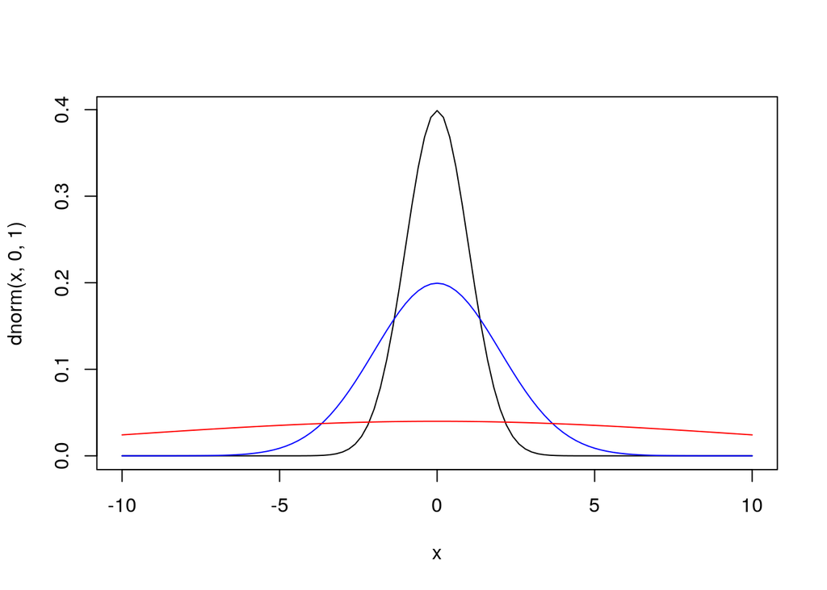

```r
curve(dnorm(x, 0, 1), from = -10, to = 10)
curve(dnorm(x, 0, 2), from = -10, to = 10, add = T, col = "blue")
curve(dnorm(x, 0, 10), from = -10, to = 10, add = T, col = "red")
```

We have little information about the dispersion parameter, so we will define a more diffuse prior than brms.

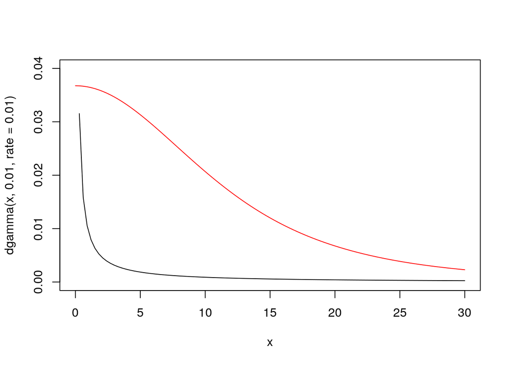

```r
## Prior chosen by brms
curve(dgamma(x, 0.01, rate = 0.01), to = 30, ylim = c(0, 0.040))
## Prior we will define
curve(dstudent_t(x, 3, 0, 10), to = 30, add = T, col = "red")
```

### Prior predictive checks

```r
## Set prior with sd = 1
priors_1 <- c(prior(normal(0,1), class = b),
            prior(normal(0,1), class = Intercept),
            prior(student_t(3, 0, 10), class = phi))
## sample from the priors
ppp_1 <- brm(formula = form, prior = priors_1,
           data = Tot, sample_prior = "only",
           chains = 1, cores = 1)
## Set prior with sd = 2
priors_2 <- c(prior(normal(0,2), class = b),
            prior(normal(0,1), class = Intercept),
            prior(student_t(3, 0, 10), class = phi))
## sample from the priors
ppp_2 <- brm(formula = form, prior = priors_2,
           data = Tot, sample_prior = "only",
           chains = 1, cores = 1)
## Set prior with sd = 2
priors_10 <- c(prior(normal(0,10), class = b),
            prior(normal(0,1), class = Intercept),
            prior(student_t(3, 0, 10), class = phi))
## sample from the priors
ppp_10 <- brm(formula = form, prior = priors_10,
           data = Tot, sample_prior = "only",
           chains = 1, cores = 1)
```

Now that we have sampled the parameters, we can extract predicted values. Predicted values, in this case, are stored in a three dimensional array defined by [samples, observations, response variables]

```r
pred_1 <- predict(ppp_1, summary = F, nsamples = 100)
pred_2 <- predict(ppp_2, summary = F, nsamples = 100)
pred_10 <- predict(ppp_10, summary = F, nsamples = 100)
dim(pred_1)
```

```
## [1] 100 126   5
```

We will then plot the predicted densities given the three different scales.

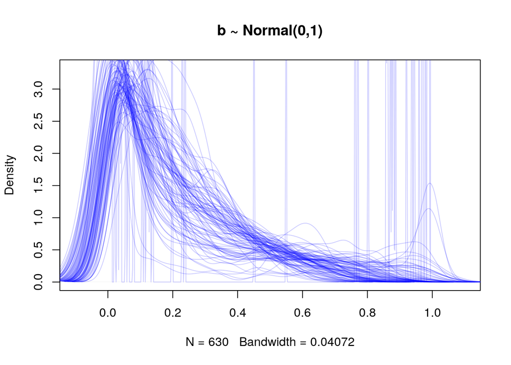

```r
plot(density(pred_1[1,,]), col = scales::alpha("blue", 0.2), main = "b ~ Normal(0,1)",
     xlim = c(-0.1, 1.1))
for(i in 2:100) lines(density(pred_1[i,,]), col = scales::alpha("blue", 0.2))
```

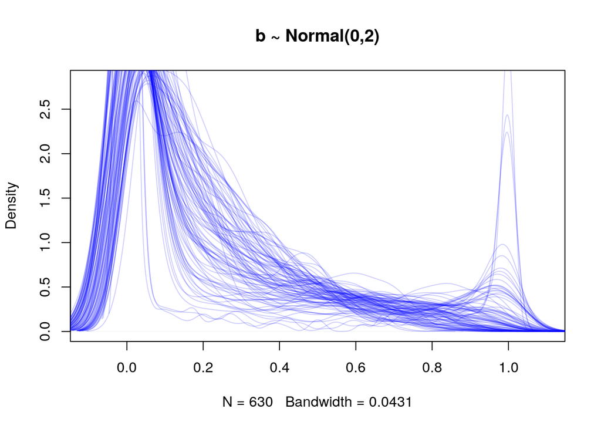

```r
plot(density(pred_2[1,,]), col = scales::alpha("blue", 0.2), main = "b ~ Normal(0,2)",
     xlim = c(-0.1, 1.1))
for(i in 2:100) lines(density(pred_2[i,,]), col = scales::alpha("blue", 0.2))
```

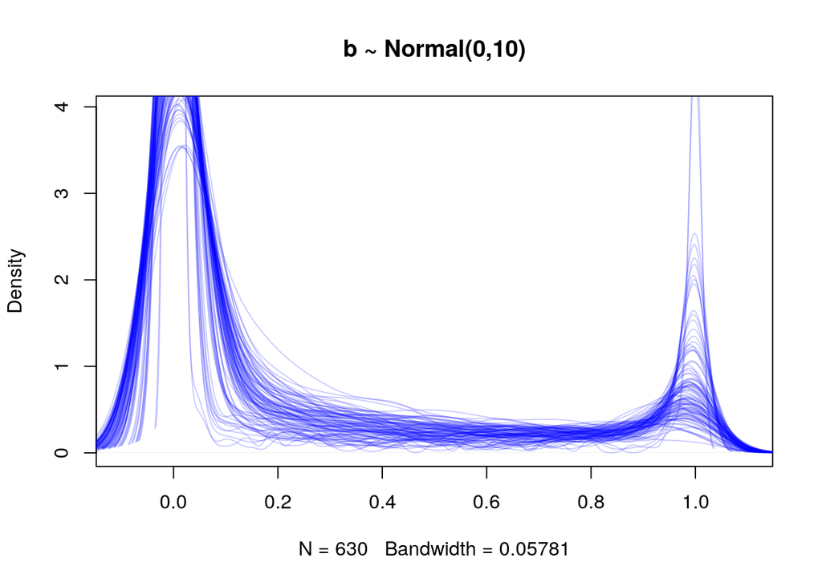

```r
plot(density(pred_10[1,,]), col = scales::alpha("blue", 0.2), main = "b ~ Normal(0,10)",
     xlim = c(-0.1, 1.1))
for(i in 2:100) lines(density(pred_10[i,,]), col = scales::alpha("blue", 0.2))
```

We can see that the higher the scale, the higher the probability that a party wins with approximately 100% of votes, which is almost impossible (in Canada…). Ironically, in that case, a greater scale of the prior leads to more specific results than a lower scale! That should make us think about diffuse priors, and why they are often inappropriate, and sometimes lead to highly unwanted results… I will let you discover the work of Jim Savage, who proposed in this [blog post](http://khakieconomics.github.io/2019/03/17/Choosing-priors-for-logit-choice-models.html), to choose prior scale based on prior predictive checks and an explicit loss function.

We will then define the priors as follow :

```r
priors <- c(prior(normal(0,1), class = b),
            prior(normal(0,1), class = Intercept),
            prior(student_t(3, 0, 10), class = phi))
```

## Model fit

Before fitting the model, we will define the number of chains we want to run in parallel. I suggest to run four chains and to exploit one less core than the number of cores available in the CPU (to allow you to continue listening to music).

```r
nchains = 4
ncores = parallel::detectCores()-1
```

We can now ask brms to create a stan program and to call the *No-U-Turn Sampler* algorithm to sample the posterior of parameters.

```r
fit <- brm(formula = form, prior = priors,
           data = Tot,
           chains = nchains, cores = ncores)
```

We can observe diagnostic values in the summary :

```r
summary(fit)
```

```
##  Family: dirichlet
##   Links: muCAQ = logit; muPQ = logit; muPLQ = logit; muQS = logit; phi = identity
## Formula: Y ~ anglais_pourc + bilingue_pourc + aucune_pourc + commun_pourc + bicycle_pourc + migrants_5ans_pourc + log_av60_pourc + agri_pourc + moins_40mille_pourc + X40_100mille_pour + loc_pourc + n_valeur_logement_mediane + n_cout_hab_loc_pourc
##    Data: Tot (Number of observations: 124)
## Samples: 4 chains, each with iter = 2000; warmup = 1000; thin = 1;
##          total post-warmup samples = 4000
##
## Population-Level Effects:
##                                 Estimate Est.Error l-95% CI u-95% CI Rhat
## muCAQ_Intercept                     1.91      0.46     1.02     2.79 1.00
## muPQ_Intercept                      2.27      0.50     1.28     3.22 1.00
## muPLQ_Intercept                     1.16      0.44     0.30     2.03 1.00
## muQS_Intercept                      1.25      0.51     0.21     2.23 1.00
## muCAQ_anglais_pourc                -1.90      0.44    -2.75    -1.03 1.00
## muCAQ_bilingue_pourc               -0.47      0.88    -2.27     1.28 1.00
## muCAQ_aucune_pourc                 -0.19      0.95    -2.06     1.68 1.00
## muCAQ_commun_pourc                 -1.40      0.58    -2.54    -0.28 1.00
## muCAQ_bicycle_pourc                -0.80      0.91    -2.60     0.97 1.00
## muCAQ_migrants_5ans_pourc          -0.40      0.91    -2.21     1.39 1.00
## muCAQ_log_av60_pourc               -0.79      0.48    -1.76     0.16 1.00
## muCAQ_agri_pourc                    0.38      0.90    -1.37     2.14 1.00
## muCAQ_moins_40mille_pourc          -0.73      0.70    -2.10     0.68 1.00
## muCAQ_X40_100mille_pour             1.93      0.79     0.37     3.49 1.00
## muCAQ_loc_pourc                     0.10      0.47    -0.78     1.03 1.00
## muCAQ_n_valeur_logement_mediane    -0.33      0.49    -1.29     0.62 1.00
## muCAQ_n_cout_hab_loc_pourc         -0.15      0.38    -0.91     0.59 1.00
## muPQ_anglais_pourc                 -2.04      0.49    -3.02    -1.14 1.00
## muPQ_bilingue_pourc                -0.49      0.90    -2.23     1.25 1.00
## muPQ_aucune_pourc                  -0.25      0.98    -2.22     1.69 1.00
## muPQ_commun_pourc                   0.07      0.62    -1.16     1.27 1.00
## muPQ_bicycle_pourc                  0.14      0.92    -1.67     1.92 1.00
## muPQ_migrants_5ans_pourc           -0.79      0.94    -2.64     1.06 1.00
## muPQ_log_av60_pourc                -0.47      0.54    -1.49     0.59 1.00
## muPQ_agri_pourc                    -0.84      0.92    -2.63     0.97 1.00
## muPQ_moins_40mille_pourc            0.43      0.81    -1.14     1.99 1.00
## muPQ_X40_100mille_pour             -1.32      0.84    -2.99     0.34 1.00
## muPQ_loc_pourc                     -0.00      0.53    -1.07     1.04 1.00
## muPQ_n_valeur_logement_mediane     -0.77      0.56    -1.87     0.31 1.00
## muPQ_n_cout_hab_loc_pourc          -0.42      0.43    -1.25     0.44 1.00
## muPLQ_anglais_pourc                 1.51      0.41     0.72     2.35 1.00
```

[output cut: 75 more lines]

```
## muQS_log_av60_pourc                 5437     3272
## muQS_agri_pourc                     8554     2943
## muQS_moins_40mille_pourc            6370     2914
## muQS_X40_100mille_pour              7858     3099
## muQS_loc_pourc                      4886     3277
## muQS_n_valeur_logement_mediane      4370     2698
## muQS_n_cout_hab_loc_pourc           3854     3074
##
## Family Specific Parameters:
##     Estimate Est.Error l-95% CI u-95% CI Rhat Bulk_ESS Tail_ESS
## phi    39.21      2.58    34.20    44.44 1.00     6754     3356
##
## Samples were drawn using sampling(NUTS). For each parameter, Eff.Sample
## is a crude measure of effective sample size, and Rhat is the potential
## scale reduction factor on split chains (at convergence, Rhat = 1).
```

Every $\hat{R}$ is egual to 1, meaning chains should have correctly converged. Bulk and Tail Effective Sample Size are superior to 100 per chains, so the estimates should be reliable. One can observe the chains with the following command :

```r
plot(fit, pars = NA)
```

## Predictions

The best way to understand the conclusion of a model is to visualize the counter-factual predictions, that is to plot the effect of a variable while the others are kept constant. Fortunately, `brms` allow doing this easily.

### English speakers

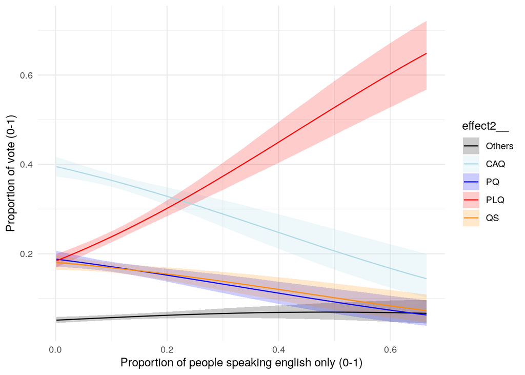

```r
p <- plot(marginal_effects(fit, categorical = T, effects = "anglais_pourc"),
                      plot = F)

p$`anglais_pourc:cats__`$data %>%
  ggplot(aes(x = effect1__)) +
  geom_ribbon(aes(ymin = lower__, ymax = upper__, fill = effect2__), alpha = 0.2) +
  geom_line(aes(y = estimate__, color = effect2__)) +
  theme_minimal() +
  xlab("Proportion of people speaking english only (0-1)") +
  ylab("Proportion of vote (0-1)") +
  scale_color_manual(values = c("black", "light blue", "blue", "red", "dark orange")) +
  scale_fill_manual(values = c("black", "light blue", "blue", "red", "dark orange"))
```

Divisions with a higher proportion of people speaking English gave an overwhelming support to the Parti Libéral du Québec, with the proportion of voters being on average 3 time higher when more than half of the population speaks only English, vs. division with no English-only speakers. Every other party had lower results in English-speaking divisions, except the aggregation of every other smaller parties, which tended to increase slightly. There is the same tendency, less exacerbated, when considering the proportion of bilingual in the population.

### Public transportation

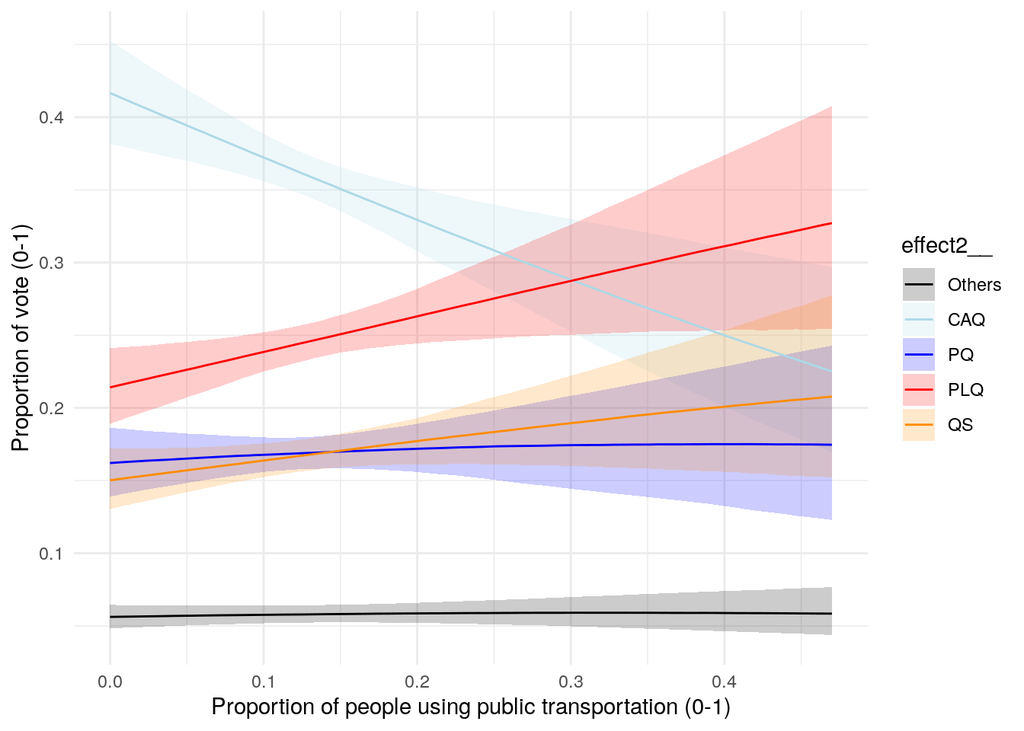

```r
p <- plot(marginal_effects(fit, categorical = T, effects = "commun_pourc"),
                      plot = F)

p$`commun_pourc:cats__`$data %>%
  ggplot(aes(x = effect1__)) +
  geom_ribbon(aes(ymin = lower__, ymax = upper__, fill = effect2__), alpha = 0.2) +
  geom_line(aes(y = estimate__, color = effect2__)) +
  theme_minimal() +
  xlab("Proportion of people using public transportation (0-1)") +
  ylab("Proportion of vote (0-1)") +
  scale_color_manual(values = c("black", "light blue", "blue", "red", "dark orange")) +
  scale_fill_manual(values = c("black", "light blue", "blue", "red", "dark orange"))
```

Coalition Avenir Québec received a far proportion of votes (up to two times less) in division where people go to work by public transportation. Both PLQ and Quebec Solidaire seemed to be favored in this electoral divisions.

### Bicycle

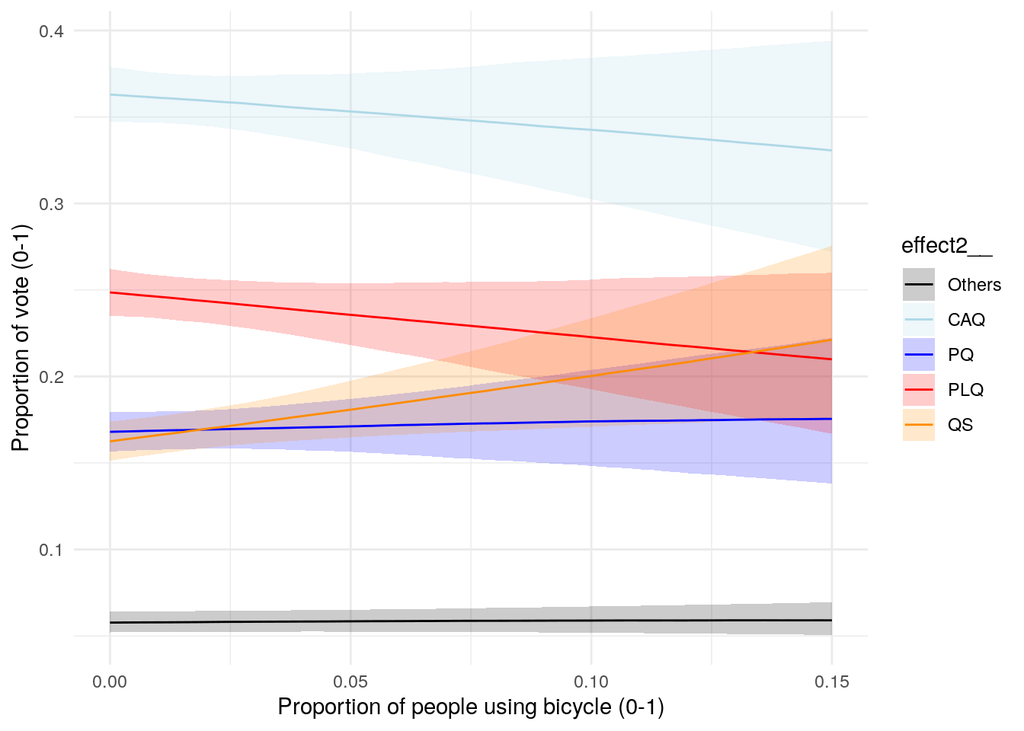

```r
p <- plot(marginal_effects(fit, categorical = T, effects = "bicycle_pourc"),
                      plot = F)

p$`bicycle_pourc:cats__`$data %>%
  ggplot(aes(x = effect1__)) +
  geom_ribbon(aes(ymin = lower__, ymax = upper__, fill = effect2__), alpha = 0.2) +
  geom_line(aes(y = estimate__, color = effect2__)) +
  theme_minimal() +
  xlab("Proportion of people using bicycle (0-1)") +
  ylab("Proportion of vote (0-1)") +
  scale_color_manual(values = c("black", "light blue", "blue", "red", "dark orange")) +
  scale_fill_manual(values = c("black", "light blue", "blue", "red", "dark orange"))
```

The more people use a bicycle to go to work, the more they tended to vote for QS, a left-oriented party. Both CAQ and PLQ results tended to decrease in that case.

### Recently immigrated people

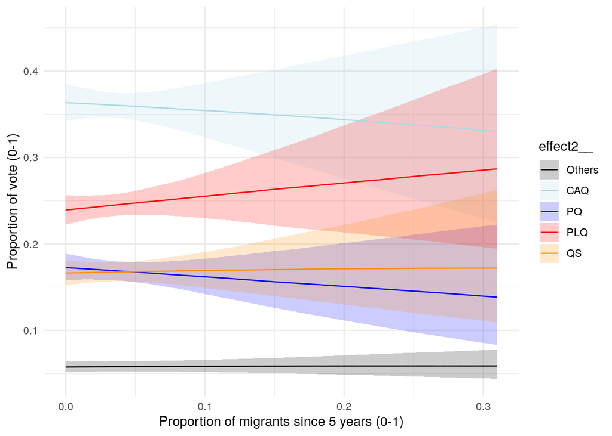

```r
p <- plot(marginal_effects(fit, categorical = T, effects = "migrants_5ans_pourc"),
                      plot = F)

p$`migrants_5ans_pourc:cats__`$data %>%
  ggplot(aes(x = effect1__)) +
  geom_ribbon(aes(ymin = lower__, ymax = upper__, fill = effect2__), alpha = 0.2) +
  geom_line(aes(y = estimate__, color = effect2__)) +
  theme_minimal() +
  xlab("Proportion of migrants since 5 years (0-1)") +
  ylab("Proportion of vote (0-1)") +
  scale_color_manual(values = c("black", "light blue", "blue", "red", "dark orange")) +
  scale_fill_manual(values = c("black", "light blue", "blue", "red", "dark orange"))
```

### Old housing

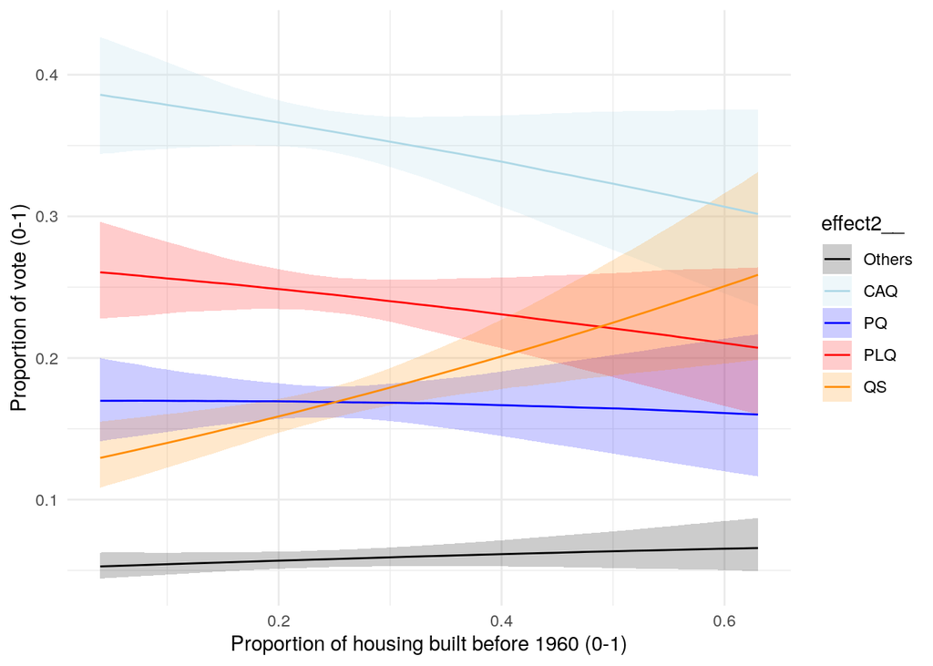

```r
p <- plot(marginal_effects(fit, categorical = T, effects = "log_av60_pourc"),
                      plot = F)

p$`log_av60_pourc:cats__`$data %>%
  ggplot(aes(x = effect1__)) +
  geom_ribbon(aes(ymin = lower__, ymax = upper__, fill = effect2__), alpha = 0.2) +
  geom_line(aes(y = estimate__, color = effect2__)) +
  theme_minimal() +
  xlab("Proportion of housing built before 1960 (0-1)") +
  ylab("Proportion of vote (0-1)") +
  scale_color_manual(values = c("black", "light blue", "blue", "red", "dark orange")) +
  scale_fill_manual(values = c("black", "light blue", "blue", "red", "dark orange"))
```

We can observe a clear and strong relationship: QS was favored in divisions in which the proportion of old houses and buildings is higher, with an approximately two-time increase among division recently built and the one with a majority of older buildings.

## Agriculture

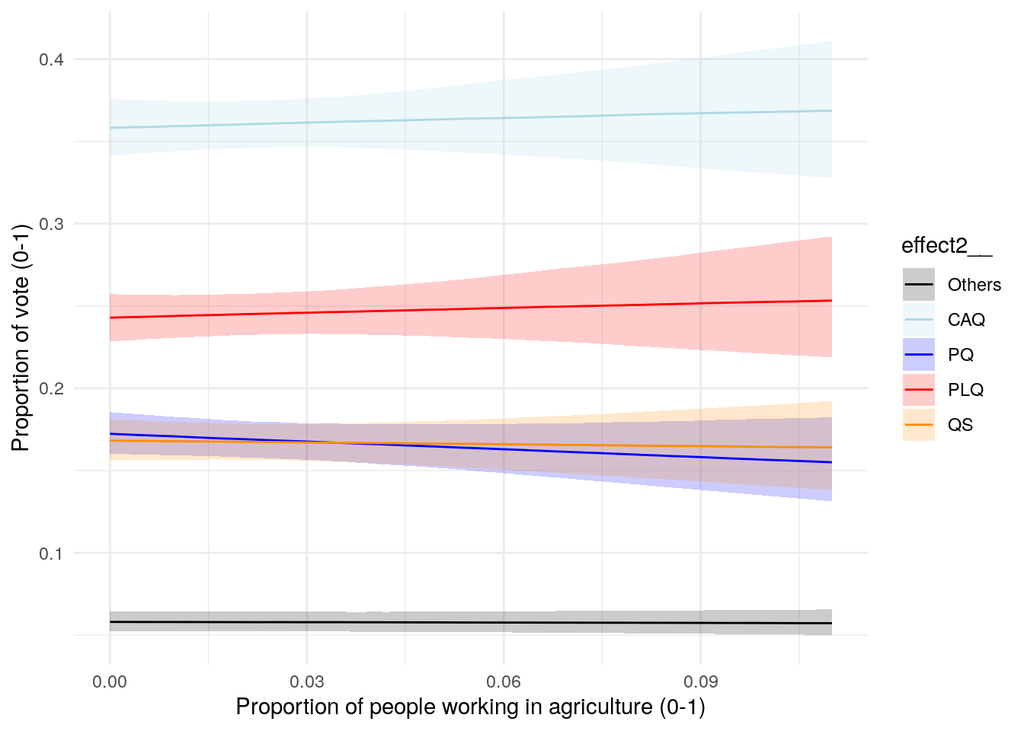

```r
p <- plot(marginal_effects(fit, categorical = T, effects = "agri_pourc"),
                      plot = F)

p$`agri_pourc:cats__`$data %>%
  ggplot(aes(x = effect1__)) +
  geom_ribbon(aes(ymin = lower__, ymax = upper__, fill = effect2__), alpha = 0.2) +
  geom_line(aes(y = estimate__, color = effect2__)) +
  theme_minimal() +
  xlab("Proportion of people working in agriculture (0-1)") +
  ylab("Proportion of vote (0-1)") +
  scale_color_manual(values = c("black", "light blue", "blue", "red", "dark orange")) +
  scale_fill_manual(values = c("black", "light blue", "blue", "red", "dark orange"))
```

We cannot see any tendency related to the proportion of people working in the agricultural sector.